# DDoS Attack Mitigation

## Entropy Under Attack

Alright, we have the graph for the entire experiments. Now we need to focus in the attack.

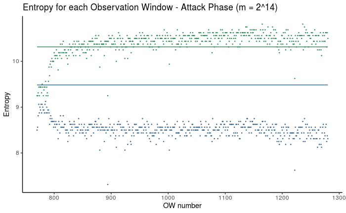

```r
get_plot_tcad_attack = function(tcad, tcad_k, log2n, log2m) {

  first = attack_first(log2n, log2m) + 1
  last  = attack_last(log2n, log2m)

  plot = get_plot_tcad(tcad %>% filter(ow>=first, ow<=last), tcad_k)

  return(plot)

}

title = "Entropy for each Observation Window - Attack Phase "

get_plot_tcad_attack(tcad_m14, tcad_m14_k, log2n, 14) + labs(title=str_c(title,"(m = 2^14)"))
```

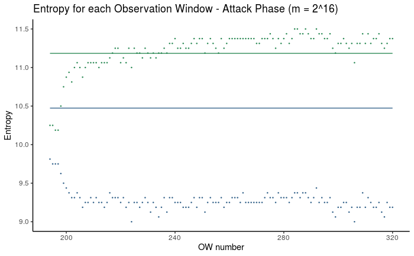

```r
get_plot_tcad_attack(tcad_m16, tcad_m16_k, log2n, 16) + labs(title=str_c(title,"(m = 2^16)"))
```

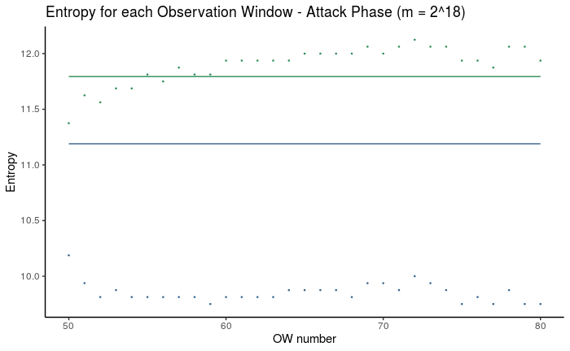

```r
get_plot_tcad_attack(tcad_m18, tcad_m18_k, log2n, 18) + labs(title=str_c(title,"(m = 2^18)"))
```

# Mitigation Studies

In this study: log2m = 14.

```r
  log2n = as.integer(24)
  n = as.integer(2^log2n)

  log2m = as.integer(14)
  m = as.integer(2^log2m)

  pcap_csv = pcap_csv_m14
```

```r
read_pcap_csv = function(log2n, log2m, pcap_csv) {

  m = as.integer(2^log2m)

  # This is the format of the CSV files we import.
  col_types = cols(
    src = col_character(),
    dst = col_character(),
    src_delta = col_character(),
    dst_delta = col_character(),
    attack = col_logical())

  packets = read_csv(pcap_csv, col_types = col_types)

  # Add index column.
  packets = packets %>% tibble::rowid_to_column("index")

  # Add an offset to compensate the pre-initializing of training coefficients.
  offset = training(log2n, log2m) * m
  packets = packets %>% mutate(index = index + offset)

  # Add OW numbers.
  packets = packets %>% mutate(ow = get_ow(index,m))

  # Adjust numeric representations of src_delta and dst_delta.

  # Convert from hexadecimal to decimal
  packets = packets %>% mutate_at(vars(src_delta, dst_delta), funs(strtoi))

  # Convert from 16-bit two's complement representation to integer representation.
  twos_complement = function(x) as.integer(ifelse(x > 32767, x - 65536, x))
  packets = packets %>% mutate_at(vars(src_delta, dst_delta), funs(twos_complement))

  return(packets)

}

packets = read_pcap_csv(log2n, log2m, pcap_csv)
```

[output not shown]

### Checking

At this point we need to check whether we can observe the first attack packet. We query the dataset at a specific points. For log2m=14, the attack begins at the fifth packet of OW 769 and lasts for a total of 512 OWs (i.e., OWs 769-1280).

```r
check_first_attack_ow = function(log2n, log2m, packets) {

  m = as.integer(2^log2m)

  attack_first_ow = attack_first(log2n, log2m)
  attack_last_ow = attack_last(log2n, log2m)

  attack_first_packet = (attack_first_ow - 1) * m + 1
  attack_last_packet  = (attack_last_ow) * m

  message(str_c(attack_first_ow, attack_last_ow, attack_first_packet, attack_last_packet, sep="\n"))

  packets %>% filter(index >= attack_first_packet)

}

check_first_attack_ow(log2n, log2m, packets)
```

```
769
1280
12582913
20971520
```

| index | src | dst | src_delta | dst_delta | attack | ow |
| --- | --- | --- | --- | --- | --- | --- |
| 12582913 | 221.32.72.235 | 1.32.254.156 | 0 | 0 | FALSE | 769 |
| 12582914 | 198.88.219.113 | 198.88.221.44 | 0 | 0 | FALSE | 769 |
| 12582915 | 43.139.101.159 | 1.34.26.143 | 0 | 0 | FALSE | 769 |
| 12582916 | 68.233.36.14 | 210.108.37.25 | 0 | 0 | FALSE | 769 |
| 12582917 | 192.120.148.227 | 71.126.222.64 | 0 | 0 | TRUE | 769 |
| 12582918 | 153.193.46.93 | 115.46.206.104 | 0 | 0 | FALSE | 769 |
| 12582919 | 51.173.229.255 | 71.126.222.64 | 0 | 0 | TRUE | 769 |
| 12582920 | 202.1.175.252 | 71.126.222.64 | 0 | 0 | TRUE | 769 |
| 12582921 | 192.95.27.190 | 71.126.222.64 | 0 | 0 | TRUE | 769 |
| 12582922 | 51.173.229.255 | 71.126.222.64 | 0 | 0 | TRUE | 769 |

[output cut: 990 more lines]

## Typical Deltas

Question: for each OW, what are the typical frequency deltas for attack packets?

For log2m=14, packet diversion begins at OW 770. DEFCON uses OWs 769 and 768 as a reference.

```r
summarize_deltas = function (log2n, log2m, packets) {

  attack_first_ow = attack_first(log2n, log2m) + 1
  attack_last_ow = attack_last(log2n, log2m)

  result = packets %>%
    filter(ow >= attack_first_ow, ow<=attack_last_ow) %>%
    group_by(ow, attack) %>%
    summarize(
              srcq0=min(src_delta),
              srcq1=quantile(src_delta, 0.25),
              srcq2=median(src_delta),
              srcq3=quantile(src_delta, 0.75),
              srqq4=max(src_delta),
              dstq0=min(dst_delta),
              dstq1=quantile(dst_delta, 0.25),
              dstq2=median(dst_delta),
              dstq3=quantile(dst_delta, 0.75),
              dstq4=max(dst_delta),
              srciqr=IQR(src_delta),
              dstiqr=IQR(dst_delta))

  return(result)

}

deltas = summarize_deltas(log2n, log2m, packets)

deltas
```

| ow | attack | srcq0 | srcq1 | srcq2 | srcq3 | srqq4 | dstq0 | dstq1 | dstq2 | dstq3 | dstq4 | srciqr | dstiqr |
| --- | --- | --- | --- | --- | --- | --- | --- | --- | --- | --- | --- | --- | --- |
| 770 | FALSE | -275 | -8.00 | -1.0 | 4.00 | 274 | -278 | -11.00 | -1 | 3.00 | 277 | 12.00 | 14.00 |
| 770 | TRUE | 0 | 541.00 | 560.0 | 690.00 | 741 | -3 | 3271.00 | 3271 | 3271.00 | 3271 | 149.00 | 0.00 |
| 771 | FALSE | -118 | -7.00 | -1.0 | 5.00 | 128 | -140 | -6.00 | 0 | 5.00 | 184 | 12.00 | 11.00 |
| 771 | TRUE | 1 | 540.00 | 540.0 | 763.00 | 763 | -3 | 3284.00 | 3284 | 3284.00 | 3284 | 223.00 | 0.00 |
| 772 | FALSE | -372 | -7.00 | -1.0 | 5.00 | 220 | -363 | -7.00 | 0 | 6.00 | 208 | 12.00 | 13.00 |
| 772 | TRUE | -8 | 74.00 | 490.0 | 622.00 | 831 | -15 | 3144.00 | 3144 | 3144.00 | 3144 | 548.00 | 0.00 |
| 773 | FALSE | -313 | -7.00 | -1.0 | 4.00 | 294 | -330 | -8.00 | -1 | 4.00 | 294 | 11.00 | 12.00 |
| 773 | TRUE | -8 | 23.00 | 416.0 | 602.00 | 602 | -36 | 26.00 | 2646 | 2646.00 | 2646 | 579.00 | 2620.00 |
| 774 | FALSE | -131 | -7.00 | -1.0 | 4.00 | 125 | -147 | -10.00 | -1 | 4.00 | 97 | 11.00 | 14.00 |
| 774 | TRUE | -17 | 107.00 | 249.0 | 1060.00 | 1060 | -29 | 114.00 | 2252 | 2252.00 | 2252 | 953.00 | 2138.00 |

[output cut: 990 more lines]

```r
NA
```

Can we graph it?

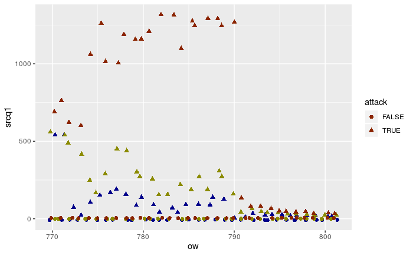

```r
dot_size = 2.0

attack_first_ow = attack_first(log2n, log2m) + 1
attack_last_ow = attack_last(log2n, log2m)
cut = attack_first_ow + 32

delta_plot_options = list(
  geom_point(mapping = aes(y=srcq1), color="blue4", position="jitter", size=dot_size),
  geom_point(mapping = aes(y=srcq2), color="yellow4", position="jitter", size=dot_size),
  geom_point(mapping = aes(y=srcq3), color="orangered4", position="jitter", size=dot_size))

deltas %>% filter(ow<cut) %>%
  ggplot(mapping = aes(x=ow, shape=attack)) + delta_plot_options
```

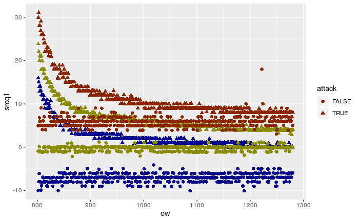

```r
deltas %>% filter(ow>=cut) %>%
  ggplot(mapping = aes(x=ow, shape=attack)) + delta_plot_options
```

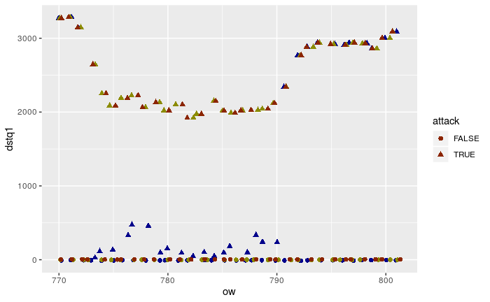

```r
delta_plot_options = list(
  geom_point(mapping = aes(y=dstq1), color="blue4", position="jitter", size=dot_size),
  geom_point(mapping = aes(y=dstq2), color="yellow4", position="jitter", size=dot_size),
  geom_point(mapping = aes(y=dstq3), color="orangered4", position="jitter", size=dot_size))

deltas %>% filter(ow<cut) %>%
  ggplot(mapping = aes(x=ow, shape=attack)) + delta_plot_options
```

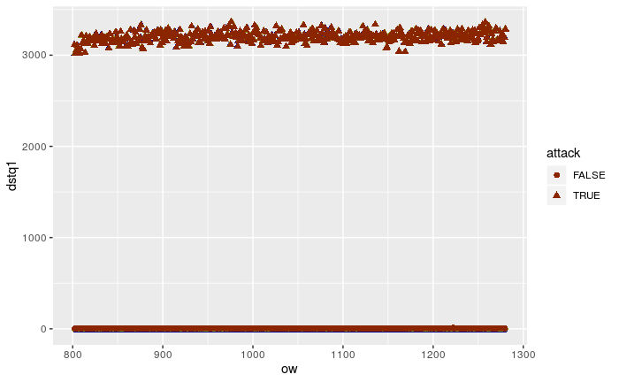

```r
deltas %>% filter(ow>=cut) %>%
  ggplot(mapping = aes(x=ow, shape=attack)) + delta_plot_options
```

## Defining a threshold

Let’s set an arbitrary threshold and a function which indicates whether or not to divert a given packet.

```r
src_threshold = 0
dst_threshold = 16

#divert = function(src_delta, dst_delta) (src_delta >= threshold)
#divert = function(src_delta, dst_delta) (dst_delta >= threshold)
#divert = function(src_delta, dst_delta) (src_delta >= threshold && dst_delta >= threshold)

divert = function(src_delta, dst_delta) (dst_delta >= dst_threshold)
```

## Address Counts

```r
src_distinct = packets %>% filter(ow >= attack_first_ow, ow <= attack_last_ow) %>% group_by(ow, attack, src_delta) %>% summarize(srcs=n_distinct(src))

src_distinct
```

| ow | attack | src_delta | srcs |
| --- | --- | --- | --- |
| 770 | FALSE | -275 | 1 |
| 770 | FALSE | -197 | 1 |
| 770 | FALSE | -141 | 1 |
| 770 | FALSE | -82 | 1 |
| 770 | FALSE | -77 | 1 |
| 770 | FALSE | -75 | 1 |
| 770 | FALSE | -72 | 1 |
| 770 | FALSE | -63 | 2 |
| 770 | FALSE | -61 | 1 |
| 770 | FALSE | -54 | 1 |

[output cut: 990 more lines]

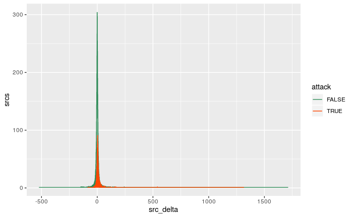

```r
src_distinct %>%
  ggplot(mapping=aes(x=src_delta, y=srcs, color=attack)) +
  geom_line() +
  scale_color_manual(values=c("seagreen4", "orangered1"))
```

```r
dst_distinct = packets %>% filter(ow >= attack_first_ow, ow <= attack_last_ow) %>% group_by(ow, attack, dst_delta) %>% summarize(dsts=n_distinct(dst))

dst_distinct
```

| ow | attack | dst_delta | dsts |
| --- | --- | --- | --- |
| 770 | FALSE | -278 | 1 |
| 770 | FALSE | -198 | 1 |
| 770 | FALSE | -133 | 1 |
| 770 | FALSE | -87 | 1 |
| 770 | FALSE | -81 | 1 |
| 770 | FALSE | -71 | 2 |
| 770 | FALSE | -65 | 1 |
| 770 | FALSE | -60 | 1 |
| 770 | FALSE | -59 | 1 |
| 770 | FALSE | -57 | 1 |

[output cut: 990 more lines]

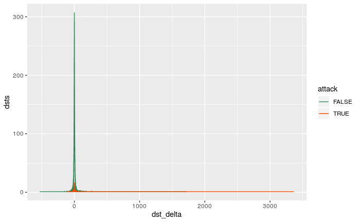

```r
dst_distinct %>%
  ggplot(mapping=aes(x=dst_delta, y=dsts, color=attack)) +
  geom_line() +
  scale_color_manual(values=c("seagreen4", "orangered1"))
```

## Classification Stats

Base Stats

```r
stats = function(packets, log2n, log2m) {

  attack_first_ow = attack_first(log2n, log2m) + 1
  attack_last_ow = attack_last(log2n, log2m)

  query = packets %>% filter(ow>=attack_first_ow, ow<=attack_last_ow)

  true_evil = query %>% filter(attack==TRUE) %>% tally()
  true_good = query %>% filter(attack==FALSE) %>% tally()
  message("True evil: ", true_evil, " True good: ", true_good, " Total: ", true_evil + true_good)

  class_evil = query %>% filter(divert(src_delta,dst_delta)) %>% tally()
  class_good = query %>% filter(!divert(src_delta,dst_delta)) %>% tally()
  message("Class evil: ", class_evil, " Class good: ", class_good, " Total: ", class_evil + class_good)

  error_evil = query %>% filter(!divert(src_delta,dst_delta), attack==TRUE)  %>% tally()
  error_good = query %>% filter(divert(src_delta,dst_delta), attack==FALSE) %>% tally()

  message("FNcount: ", error_evil, " FPcount: ", error_good, " Total: ", error_evil + error_good)
  message("FNR: ", round(error_evil/true_evil,4), " FPR: ", round(error_good/true_good,4))

}

stats(packets, log2n, log2m)
```

```
True evil: 1673844 True good: 6698380 Total: 8372224
Class evil: 2445589 Class good: 5926635 Total: 8372224
FNcount: 46617 FPcount: 818362 Total: 864979
FNR: 0.0279 FPR: 0.1222
```

Confidence Intervals

Both TPR and FPR are proportions whose values we need to estimate.

Let X be a random variable whose value is 1 when a classification succeeds, and 0 otherwise. Consequently, X follows a a Bernoulli distribution with probability p. We can use our sample to estimate the mean value of p. This sample mean has a sampling error approximately equal to sqrt(p * (1-p) / n), where n is the sample size (the total number of classification events).

```r
stats_ci = function(packets, log2n, log2m) {

  attack_first_ow = attack_first(log2n, log2m) + 1
  attack_last_ow = attack_last(log2n, log2m)
  attack_length = attack_last_ow - attack_first_ow + 1
  m = 2^log2m

  tpr = packets %>%
    filter(ow>=attack_first_ow, ow<=attack_last_ow, attack==TRUE, divert(src_delta, dst_delta)==TRUE) %>%
    group_by(ow) %>%
    summarize(n = n()) %>%
    summarize(mean = mean(n) / (0.2 * m), margin = qnorm(0.975) * sd(n)/sqrt(attack_length) / (0.2 * m))

  fpr = packets %>%
    filter(ow>=attack_first_ow, ow<=attack_last_ow, attack==FALSE, divert(src_delta, dst_delta)==TRUE) %>%
    group_by(ow) %>%
    summarize(n = n()) %>%
    summarize(mean = mean(n) / (0.8 * m), margin = qnorm(0.975) * sd(n)/sqrt(attack_length) / (0.8 * m))


  message(str_c("TPR: ", round(tpr$mean,6), " ± ", round(tpr$margin,6)))
  message(str_c("FPR: ", round(fpr$mean,6), " ± ", round(fpr$margin,6)))

}

stats_ci(packets, log2n, log2m)
```

```
TPR: 0.971801 ± 0.002222
FPR: 0.122184 ± 0.002538
```

## Classification Charts

It is interesting to observe what happens **over time**, OW after OW.

```r
graph_true_good = function() query %>% filter(attack==FALSE) %>% summarize(n=n()) %>% ggplot(mapping=aes(x=ow,y=n)) + geom_point() + ggtitle("True Good")
graph_true_evil = function() query %>% filter(attack==TRUE)  %>% summarize(n=n()) %>% ggplot(mapping=aes(x=ow,y=n)) + geom_point() + ggtitle("True Evil")

graph_class_good = function() query %>% filter(diverted==FALSE) %>% summarize(n=n()) %>% ggplot(mapping=aes(x=ow,y=n)) + geom_point() + ggtitle("Forwarded")
graph_class_evil = function() query %>% filter(diverted==TRUE)  %>% summarize(n=n()) %>% ggplot(mapping=aes(x=ow,y=n)) + geom_point() + ggtitle("Diverted")

graph_false_neg = function() query %>% filter(!divert(src_delta,dst_delta), attack==TRUE)  %>% summarize(n=n()) %>% ggplot(mapping=aes(x=ow,y=n)) + geom_point() + ggtitle("False Negatives")
graph_false_pos = function()  query %>% filter(divert(src_delta,dst_delta), attack==FALSE) %>% summarize(n=n()) %>% ggplot(mapping=aes(x=ow,y=n)) + geom_point() + ggtitle("False Positives")

graph_results = function()

  query %>% group_by(ow, attack, diverted) %>% summarize(n=n()) %>%
    ggplot(mapping=aes(x=ow, y=n, color=attack, shape=diverted)) +
    geom_point(position="jitter", size=2.0) +
    #coord_cartesian(xlim=c(770,810),ylim=c(0,16384)) +
    labs(x="Observation Window", y="Packet Count", title ="Classification Results") +
    scale_x_continuous(expand=expand_scale(add=0)) +
    scale_y_continuous(expand=expand_scale(add=0)) +
    scale_color_manual(values=c("seagreen4", "orangered1")) +
    theme_classic()
```

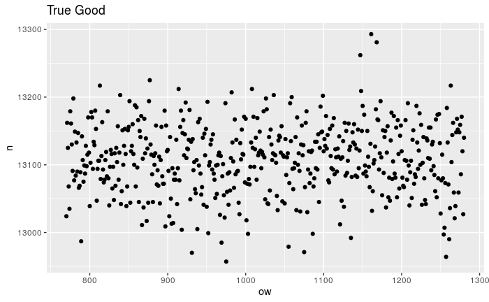

```r
attack_first_ow = attack_first(log2n, log2m) + 1
attack_last_ow = attack_last(log2n, log2m)

query = packets %>%
  filter(ow>=attack_first_ow, ow<=attack_last_ow) %>%
  mutate(diverted=divert(src_delta,dst_delta)) %>%
  group_by(ow)

graph_true_good()
```

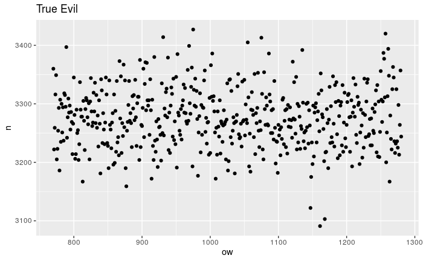

```r
graph_true_evil()
```

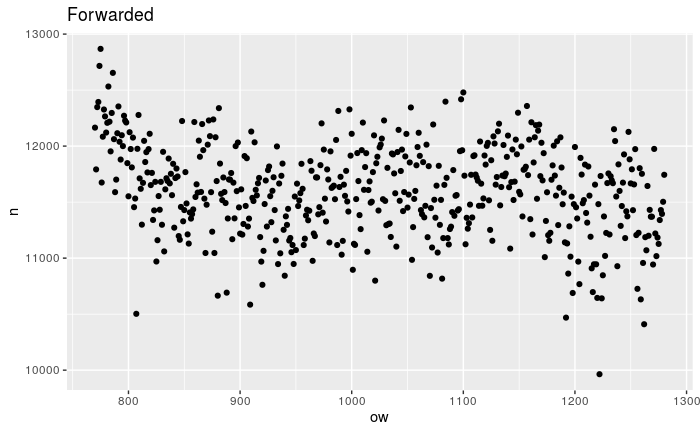

```r
graph_class_good()
```

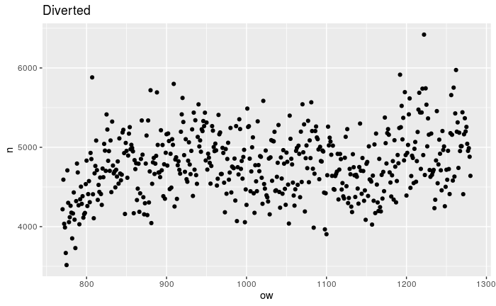

```r
graph_class_evil()
```

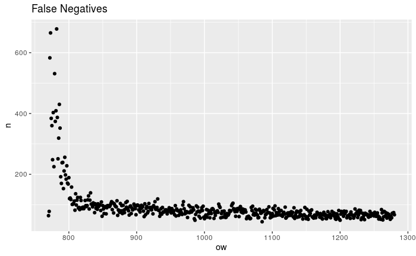

```r
graph_false_neg()
```

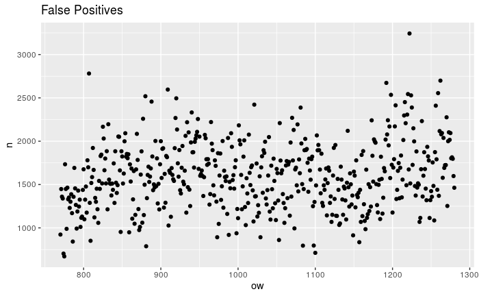

```r
graph_false_pos()
```

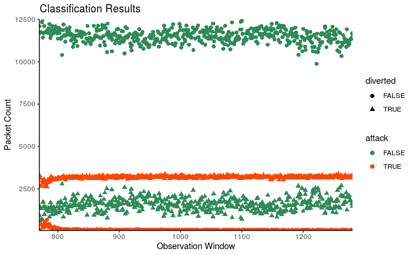

```r
graph_results()
```

```r
NA
NA
NA
NA
NA
```

```r
mitigation_out = packets %>%
  filter(ow>=attack_first_ow, ow<=attack_last_ow) %>%
  mutate(diverted=(src_delta>=src_threshold)) %>%
  group_by(ow, attack, diverted) %>%
  summarize(n=n())

mitigation_out
```

| ow | attack | diverted | n |
| --- | --- | --- | --- |
| 770 | FALSE | FALSE | 7012 |
| 770 | FALSE | TRUE | 6012 |
| 770 | TRUE | TRUE | 3360 |
| 771 | FALSE | FALSE | 6633 |
| 771 | FALSE | TRUE | 6529 |
| 771 | TRUE | TRUE | 3222 |
| 772 | FALSE | FALSE | 6737 |
| 772 | FALSE | TRUE | 6388 |
| 772 | TRUE | FALSE | 174 |
| 772 | TRUE | TRUE | 3085 |

[output cut: 990 more lines]

If we analyze **only the first 30 OWs under attack**, with a threshold equal to 16, we divert ~86% of the attack, while keeping ~90% of the good traffic in the original path.

## Log2m = 16

## Log2m = 18

# Points to Ponder

For each OW, how many different attack sources are there?

How do our findings correlate with TCAD measurements?

What else can we do?